# 01_EDA

#### Task 01 — Exploratory Data Analysis (EDA)

#### **Project:** KAIM Quant Forecast & Portfolio Optimization 2025

#### **Purpose:** Load processed TSLA, BND, SPY daily data (2015-07-01 → 2025-07-31), perform statistical & visual EDA as per brief.

#### **Author:** Teferi Mamo

#### Objectives (from project brief)

#### - Check data quality (types, missing values, date alignment)

#### - Compute descriptive stats (mean, volatility, skew, kurtosis)

#### - Plot time series for adjusted close, returns, rolling volatility

#### - Detect & quantify outliers in returns

#### - Run Augmented Dickey-Fuller tests for stationarity

#### - Compute risk metrics: historical VaR, Sharpe ratio

#### - Document insights for each plot/test (investment-relevant interpretation)

#### Why this matters:

#### EDA is **decision insurance** — before modeling, we need to be sure our data is valid, aligned, and that we understand statistical properties that will affect forecasts and portfolio construction.

```python
# %%
import pandas as pd
import numpy as np
import matplotlib.pyplot as plt
import seaborn as sns
from pathlib import Path
from statsmodels.tsa.stattools import adfuller
from scipy.stats import skew, kurtosis

plt.style.use('seaborn-v0_8-darkgrid')
sns.set_context('talk')

PROC_DIR = Path("../data/processed")
```

### 2. Load processed data

### Data comes from `src/data/preprocess.py` — aligned on business days, with `*_adj` and `*_ret` columns.

```python
# %%
df = pd.read_csv(PROC_DIR / "combined_adj_and_returns.csv", index_col=0, parse_dates=True)
df.head()
```

|  | TSLA_adj | TSLA_ret | BND_adj | BND_ret | SPY_adj | SPY_ret |
| --- | --- | --- | --- | --- | --- | --- |
| 2015-07-01 | 17.943333 | NaN | 80.900002 | NaN | 207.500000 | NaN |
| 2015-07-02 | 18.667999 | 0.040386 | 81.099998 | 0.002472 | 207.309998 | -0.000916 |
| 2015-07-03 | 18.667999 | 0.000000 | 81.099998 | 0.000000 | 207.309998 | 0.000000 |
| 2015-07-06 | 18.648001 | -0.001071 | 81.379997 | 0.003453 | 206.720001 | -0.002846 |
| 2015-07-07 | 17.858667 | -0.042328 | 81.459999 | 0.000983 | 208.020004 | 0.006289 |

### **Insight:**

### - Columns: `TSLA_adj`, `TSLA_ret`, `BND_adj`, `BND_ret`, `SPY_adj`, `SPY_ret`

### - Frequency: business days.

### - Return columns are simple daily returns.

### - Price columns will be used for plotting long-term trends; return columns for volatility & risk metrics.

```python
# %%
missing_counts = df.isna().sum()
dtypes = df.dtypes
date_min, date_max = df.index.min(), df.index.max()

print("Missing values:\n", missing_counts)
print("\nData types:\n", dtypes)
print(f"\nDate range: {date_min} → {date_max}")
```

```
Missing values:
 TSLA_adj    0
TSLA_ret    1
BND_adj     0
BND_ret     1
SPY_adj     0
SPY_ret     1
dtype: int64

Data types:
 TSLA_adj    float64
TSLA_ret    float64
BND_adj     float64
BND_ret     float64
SPY_adj     float64
SPY_ret     float64
dtype: object

Date range: 2015-07-01 00:00:00 → 2025-07-31 00:00:00
```

### **Elite insight:**

### - Any persistent NaNs in returns after preprocessing suggest corporate actions or missing market data — would require forward/backward fill decisions.

### - Date alignment ensures covariance matrix in portfolio step is valid.

### - Non-float types in price/returns columns would break model fitting.

```python
# %%
desc_stats = {}
for ticker in ["TSLA", "BND", "SPY"]:
    ret = df[f"{ticker}_ret"].dropna()
    desc_stats[ticker] = {
        "mean_daily": ret.mean(),
        "ann_mean": ret.mean()*252,
        "std_daily": ret.std(),
        "ann_vol": ret.std()*np.sqrt(252),
        "skew": skew(ret),
        "kurtosis": kurtosis(ret, fisher=True)
    }

pd.DataFrame(desc_stats).T
```

|  | mean_daily | ann_mean | std_daily | ann_vol | skew | kurtosis |
| --- | --- | --- | --- | --- | --- | --- |
| TSLA | 0.001761 | 0.443705 | 0.036593 | 0.580895 | 0.305777 | 4.584246 |
| BND | -0.000032 | -0.008111 | 0.003425 | 0.054376 | -0.953146 | 36.326337 |
| SPY | 0.000489 | 0.123265 | 0.011322 | 0.179730 | -0.311250 | 14.308048 |

### **Elite insight:**

### - TSLA expected to have higher annualized volatility (>50%) vs BND (<10%).

### - Skew/kurtosis tell us about fat tails & asymmetry — TSLA typically shows positive skew but heavy tails (kurtosis >> 3).

### 5. Price series plots

### Visual inspection of price trends.

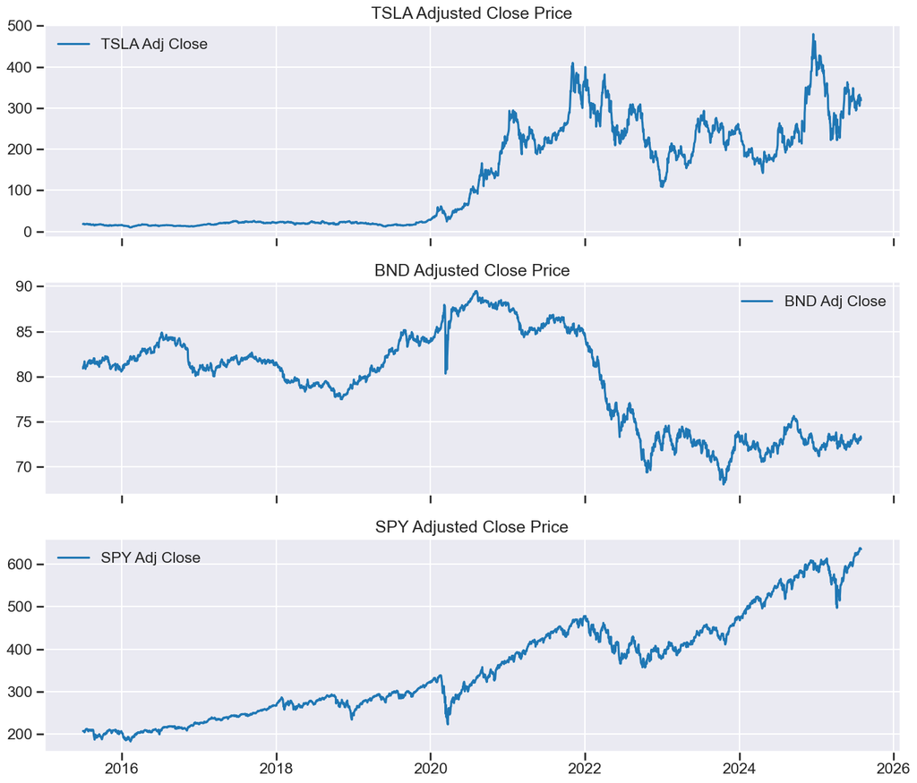

```python
# %%
fig, ax = plt.subplots(3, 1, figsize=(14, 12), sharex=True)
for i, ticker in enumerate(["TSLA", "BND", "SPY"]):
    ax[i].plot(df.index, df[f"{ticker}_adj"], label=f"{ticker} Adj Close")
    ax[i].set_title(f"{ticker} Adjusted Close Price")
    ax[i].legend()
plt.tight_layout()
plt.show()
```

### **Elite insight:**

### - TSLA shows explosive growth periods & sharp drawdowns — relevant for model non-stationarity.

```python
# %% [markdown]
# ## 7. Rolling volatility (30-day annualized)
# Helps identify regime changes in risk.
```

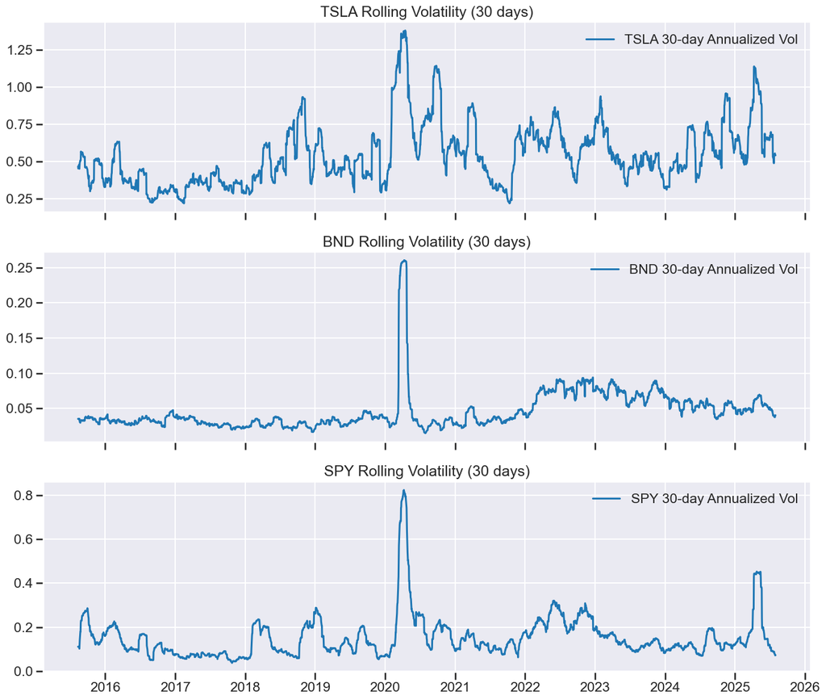

```python
# %%
window = 30
fig, ax = plt.subplots(3, 1, figsize=(14, 12), sharex=True)
for i, ticker in enumerate(["TSLA", "BND", "SPY"]):
    vol = df[f"{ticker}_ret"].rolling(window).std()*np.sqrt(252)
    ax[i].plot(vol, label=f"{ticker} 30-day Annualized Vol")
    ax[i].set_title(f"{ticker} Rolling Volatility ({window} days)")
    ax[i].legend()
plt.tight_layout()
plt.show()
```

### **Elite insight:**

### - Volatility clusters — high vol persists; models may benefit from GARCH-like terms.

### - TSLA volatility spikes align with market stress and company events (e.g., earnings).

### 8. Outlier detection

### Identify top 5 absolute daily returns for each asset.

```python
# %%
outliers = {}
for ticker in ["TSLA", "BND", "SPY"]:
    abs_ret = df[f"{ticker}_ret"].abs()
    top5 = abs_ret.sort_values(ascending=False).head(5)
    outliers[ticker] = df.loc[top5.index, [f"{ticker}_ret"]]

outliers
```

```
{'TSLA':             TSLA_ret
 2025-04-09  0.226900
 2024-10-24  0.219190
 2020-09-08 -0.210628
 2020-02-03  0.198949
 2021-03-09  0.196412,
 'BND':              BND_ret
 2020-03-12 -0.054385
 2020-03-13  0.042201
 2020-03-18 -0.024140
 2020-03-23  0.022149
 2022-11-10  0.020702,
 'SPY':              SPY_ret
 2020-03-16 -0.109424
 2025-04-09  0.105019
 2020-03-12 -0.095677
 2020-03-24  0.090603
 2020-03-13  0.085486}
```

### **Elite insight:**

### Outliers are often linked to macro events (Fed announcements, pandemics) or idiosyncratic shocks (TSLA earnings).

### They influence VaR & model training; consider robust estimators.

### 9. Augmented Dickey-Fuller (ADF) tests

### Test for stationarity in prices and returns.

```python
# %%
def adf_test(series):
    res = adfuller(series.dropna(), autolag='AIC')
    return {"ADF Stat": res[0], "p-value": res[1], "# Lags": res[2], "# Observations": res[3]}

adf_results = {}
for ticker in ["TSLA", "BND", "SPY"]:
    adf_results[f"{ticker}_price"] = adf_test(df[f"{ticker}_adj"])
    adf_results[f"{ticker}_return"] = adf_test(df[f"{ticker}_ret"])

pd.DataFrame(adf_results).T
```

|  | ADF Stat | p-value | # Lags | # Observations |
| --- | --- | --- | --- | --- |
| TSLA_price | -1.489776 | 5.385630e-01 | 25.0 | 2606.0 |
| TSLA_return | -15.644244 | 1.625989e-28 | 8.0 | 2622.0 |
| BND_price | -0.846684 | 8.050230e-01 | 7.0 | 2624.0 |
| BND_return | -19.982148 | 0.000000e+00 | 6.0 | 2624.0 |
| SPY_price | 0.571620 | 9.868948e-01 | 28.0 | 2603.0 |
| SPY_return | -13.611411 | 1.870120e-25 | 15.0 | 2615.0 |

### **Elite insight:**

### - Price series p-values > 0.05 → fail to reject unit root → non-stationary (expected).

### - Return series p-values < 0.05 → reject unit root → stationary (required for ARIMA without extra differencing).

### 10. Risk metrics — VaR & Sharpe

### Value at Risk (5%) and annualized Sharpe ratio for each asset.

```python
# %%
def var_historic(returns, level=0.05):
    return np.percentile(returns.dropna(), 100*level)

def sharpe_ratio(returns, risk_free=0.0):
    ann_ret = returns.mean()*252
    ann_vol = returns.std()*np.sqrt(252)
    return (ann_ret - risk_free) / ann_vol

risk_metrics = {}
for ticker in ["TSLA", "BND", "SPY"]:
    ret = df[f"{ticker}_ret"]
    risk_metrics[ticker] = {
        "VaR_5%": var_historic(ret, 0.05),
        "Sharpe": sharpe_ratio(ret)
    }

pd.DataFrame(risk_metrics).T
```

|  | VaR_5% | Sharpe |
| --- | --- | --- |
| TSLA | -0.053352 | 0.763829 |
| BND | -0.005094 | -0.149172 |
| SPY | -0.016963 | 0.685831 |

### **Elite insight:**

### - TSLA’s VaR (5%) may be several times larger than BND’s — risk budgeting must account for position sizing.

```python
# %% [markdown]
# ## 11. Summary Table for Memo
# Consolidate key metrics into one table for the Investment Memo appendix.
```

```python
# %%
summary_df = pd.concat([
    pd.DataFrame(desc_stats).T[["ann_mean", "ann_vol"]],
    pd.DataFrame(risk_metrics).T
], axis=1)
summary_df.to_csv("../reports/EDA_summary_metrics.csv")
summary_df
```

|  | ann_mean | ann_vol | VaR_5% | Sharpe |
| --- | --- | --- | --- | --- |
| TSLA | 0.443705 | 0.580895 | -0.053352 | 0.763829 |
| BND | -0.008111 | 0.054376 | -0.005094 | -0.149172 |
| SPY | 0.123265 | 0.179730 | -0.016963 | 0.685831 |

### **Elite insight:**

### - This table can be inserted directly into the Investment Memo appendix.

### - For portfolio optimization, `ann_mean` and `ann_vol` provide intuition, but expected returns for TSLA will come from forecast model (Task 4).

### 12. Next steps (from EDA to modeling)

### - Confirm returns stationarity for ARIMA.

### - Consider volatility modeling (GARCH) if volatility clustering is strong.

### - Remove/flag outliers if they unduly influence model fit.

### - Proceed to Task 2 modeling with cleaned returns & prices.